# Interactive effect of temp and land use on nestling growth, nestling cort, and adult visitation rate

## Cort across temp and habitat: TRES, orchard

For updated model based on DAG, squared temp is supported, but my guess is also that this is way overfit to too few data:

| model | npar | AIC | BIC | logLik | deviance | Chisq | Df | Pr(>Chisq) |
| --- | --- | --- | --- | --- | --- | --- | --- | --- |
| no sq | 8 | 28.80786 | 33.32746 | -6.403930 | 12.807861 | NA | NA | NA |
| sq max temp | 9 | 23.75399 | 28.83853 | -2.876993 | 5.753986 | 7.053875 | 1 | 0.007909396 |

```
## Linear mixed model fit by REML. t-tests use Satterthwaite's method [
## lmerModLmerTest]
## Formula:
## cort_s1_scaled ~ meanmaxtempI_scaled + age_scaled + juliandate_scaled +
##     (1 | year) + (1 | site/attempt_id)
##    Data:
## dplyr::filter(g, habitat == "Orchard", Species == "TRES", !is.na(meanmaxtempI)) %>%
##     mutate(across(c(gweight, meanmaxtempI, meanmintempI, juliandate,
##         brood_size, age, cort_s1), ~scale(.x)[, 1], .names = "{.col}_scaled"),
##         meanmaxtempI_scaled_sq = meanmaxtempI_scaled * meanmaxtempI_scaled)
##
## REML criterion at convergence: 19.3
##
## Scaled residuals:
##      Min       1Q   Median       3Q      Max
## -1.28036 -0.61190 -0.01618  0.40402  1.51311
##
## Random effects:
##  Groups          Name        Variance  Std.Dev.
##  attempt_id:site (Intercept) 0.000e+00 0.0000000
##  site            (Intercept) 1.077e+00 1.0378064
##  year            (Intercept) 2.527e-10 0.0000159
##  Residual                    1.237e-01 0.3517540
## Number of obs: 13, groups:  attempt_id:site, 5; site, 2; year, 2
##
## Fixed effects:
##                     Estimate Std. Error       df t value Pr(>|t|)
## (Intercept)         -0.10392    0.74256  0.87690  -0.140  0.91383
## meanmaxtempI_scaled -0.04604    0.10726  8.00050  -0.429  0.67909
## age_scaled          -0.95049    0.16978  8.63137  -5.598  0.00039 ***
## juliandate_scaled   -0.16891    0.21211  8.82571  -0.796  0.44672
## ---
## Signif. codes:  0 '***' 0.001 '**' 0.01 '*' 0.05 '.' 0.1 ' ' 1
##
## Correlation of Fixed Effects:
##             (Intr) mnmxI_ ag_scl
## mnmxtmpI_sc -0.029
## age_scaled  -0.007 -0.307
## julndt_scld -0.042 -0.293  0.801
## optimizer (nloptwrap) convergence code: 0 (OK)
## boundary (singular) fit: see help('isSingular')
```

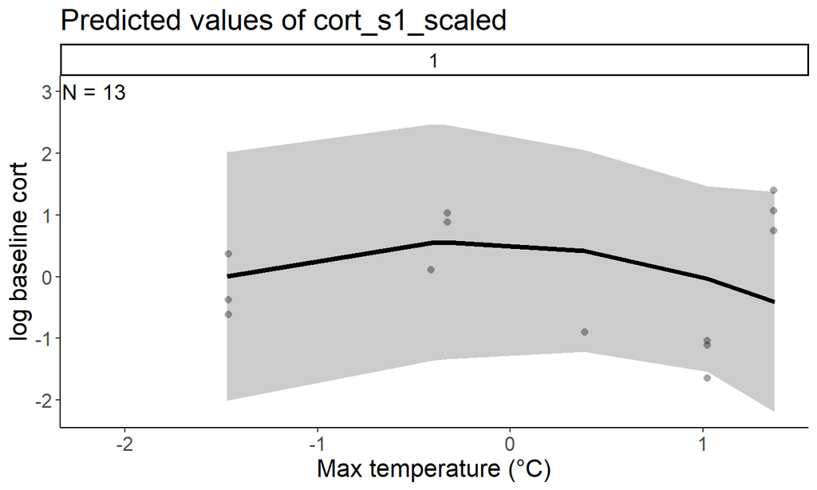

## Cort across temp and habitat: TRES, grass

For original model with min temp:

| model | npar | AIC | BIC | logLik | deviance | Chisq | Df | Pr(>Chisq) |
| --- | --- | --- | --- | --- | --- | --- | --- | --- |
| no sq | 12 | 139.0960 | 161.0397 | -57.54802 | 115.0960 | NA | NA | NA |
| no min sq | 14 | 140.8353 | 166.4362 | -56.41763 | 112.8353 | 2.260765 | 2 | 0.3229098 |
| sq max and min | 15 | 141.5368 | 168.9665 | -55.76842 | 111.5368 | 1.298424 | 1 | 0.2545014 |

| model | npar | AIC | BIC | logLik | deviance | Chisq | Df | Pr(>Chisq) |
| --- | --- | --- | --- | --- | --- | --- | --- | --- |
| no sq | 12 | 139.0960 | 161.0397 | -57.54802 | 115.0960 | NA | NA | NA |
| no max sq | 13 | 141.0785 | 164.8509 | -57.53926 | 115.0785 | 0.0175044 | 1 | 0.8947437 |
| sq max and min | 15 | 141.5368 | 168.9665 | -55.76842 | 111.5368 | 3.5416840 | 2 | 0.1701896 |

```
## Linear mixed model fit by REML. t-tests use Satterthwaite's method [
## lmerModLmerTest]
## Formula: cort_s1_scaled ~ meanmaxtempI_scaled + meanmintempI_scaled +
##     meanmaxtempI_scaled * meanh_scaled + brood_size + age_scaled +
##     juliandate_scaled + (1 | year) + (1 | site/attempt_id)
##    Data: (dplyr::filter(g, habitat == "Grassland", Species == "TRES",
##     !is.na(meanmaxtempI), !is.na(cort_s1)) %>% mutate(across(c(cort_s1,
##     meanmaxtempI, meanmintempI, meanh, cort_s1_mother, age, juliandate),
##     ~scale(.x)[, 1], .names = "{.col}_scaled"), meanmaxtempI_scaled_sq = meanmaxtempI_scaled *
##     meanmaxtempI_scaled))
##
## REML criterion at convergence: 130
##
## Scaled residuals:
##      Min       1Q   Median       3Q      Max
## -2.02792 -0.73908  0.07811  0.51733  2.11823
##
## Random effects:
##  Groups          Name        Variance Std.Dev.
##  attempt_id:site (Intercept) 0.00000  0.0000
##  site            (Intercept) 0.02219  0.1490
##  year            (Intercept) 0.41008  0.6404
##  Residual                    0.81908  0.9050
## Number of obs: 46, groups:  attempt_id:site, 17; site, 3; year, 2
##
## Fixed effects:
##                                  Estimate Std. Error       df t value Pr(>|t|)
## (Intercept)                      -1.89083    0.95655  6.48468  -1.977   0.0919
## meanmaxtempI_scaled               0.14156    0.21467 14.23756   0.659   0.5201
## meanmintempI_scaled              -0.50565    0.27845 14.06922  -1.816   0.0907
## meanh_scaled                     -0.36746    0.27608  6.84956  -1.331   0.2258
## brood_size                        0.42190    0.16585 23.70061   2.544   0.0179
## age_scaled                        0.28566    0.17029 30.79734   1.677   0.1036
## juliandate_scaled                 0.33228    0.22691 24.83377   1.464   0.1556
## meanmaxtempI_scaled:meanh_scaled  0.05283    0.13723 36.49913   0.385   0.7025
##
## (Intercept)                      .
## meanmaxtempI_scaled
## meanmintempI_scaled              .
## meanh_scaled
## brood_size                       *
## age_scaled
## juliandate_scaled
## meanmaxtempI_scaled:meanh_scaled
## ---
## Signif. codes:  0 '***' 0.001 '**' 0.01 '*' 0.05 '.' 0.1 ' ' 1
##
## Correlation of Fixed Effects:
##             (Intr) mnmxI_ mnmnI_ mnh_sc brd_sz ag_scl jlndt_
## mnmxtmpI_sc -0.232
## mnmntmpI_sc  0.006 -0.388
## meanh_scald -0.376  0.217  0.535
## brood_size  -0.847  0.279 -0.124  0.299
## age_scaled  -0.188  0.121 -0.462 -0.324  0.307
## julndt_scld -0.179 -0.269 -0.430 -0.319  0.262  0.447
## mnmxtmpI_:_ -0.023  0.235 -0.195  0.020  0.076  0.102 -0.071
## optimizer (nloptwrap) convergence code: 0 (OK)
## boundary (singular) fit: see help('isSingular')
```

Neither term contributes to this fit.

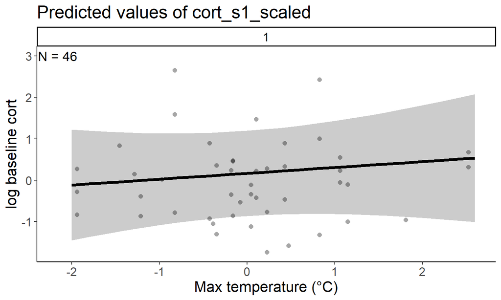

## Cort across temp and habitat: TRES, grass

For updated model based on DAG, squared temp is not supported:

| model | npar | AIC | BIC | logLik | deviance | Chisq | Df | Pr(>Chisq) |
| --- | --- | --- | --- | --- | --- | --- | --- | --- |
| no sq | 8 | 150.9983 | 165.9679 | -67.49916 | 134.9983 | NA | NA | NA |
| sq max temp | 9 | 152.8758 | 169.7167 | -67.43792 | 134.8758 | 0.1224687 | 1 | 0.7263723 |

```
## Linear mixed model fit by REML. t-tests use Satterthwaite's method [
## lmerModLmerTest]
## Formula: cort_s1_scaled ~ poly(meanmaxtempI_scaled, 2) + age_scaled +
##     juliandate_scaled + (1 | year) + (1 | site/attempt_id)
##    Data:
## dplyr::filter(g, habitat == "Grassland", Species == "TRES", !is.na(meanmaxtempI)) %>%
##     mutate(across(c(gweight, meanmaxtempI, meanmintempI, juliandate,
##         brood_size, age, cort_s1), ~scale(.x)[, 1], .names = "{.col}_scaled"),
##         meanmaxtempI_scaled_sq = meanmaxtempI_scaled * meanmaxtempI_scaled)
##
## REML criterion at convergence: 131
##
## Scaled residuals:
##      Min       1Q   Median       3Q      Max
## -1.60779 -0.73307 -0.04915  0.53536  2.52794
##
## Random effects:
##  Groups          Name        Variance  Std.Dev.
##  attempt_id:site (Intercept) 1.484e-10 1.218e-05
##  site            (Intercept) 1.208e-03 3.475e-02
##  year            (Intercept) 0.000e+00 0.000e+00
##  Residual                    1.085e+00 1.042e+00
## Number of obs: 48, groups:  attempt_id:site, 18; site, 3; year, 2
##
## Fixed effects:
##                                Estimate Std. Error        df t value Pr(>|t|)
## (Intercept)                   -0.003582   0.207817  2.071578  -0.017    0.988
## poly(meanmaxtempI_scaled, 2)1  1.673659   7.498984 36.991025   0.223    0.825
## poly(meanmaxtempI_scaled, 2)2  2.075303   6.148114 35.800914   0.338    0.738
## age_scaled                     0.038991   0.168922 42.621432   0.231    0.819
## juliandate_scaled              0.081035   0.177853 35.333162   0.456    0.651
##
## Correlation of Fixed Effects:
##             (Intr) p(I_,2)1 p(I_,2)2 ag_scl
## ply(mI_,2)1  0.559
## ply(mI_,2)2  0.458  0.879
## age_scaled  -0.304  0.093    0.100
## julndt_scld -0.279 -0.105    0.165    0.205
## optimizer (nloptwrap) convergence code: 0 (OK)
## boundary (singular) fit: see help('isSingular')
```

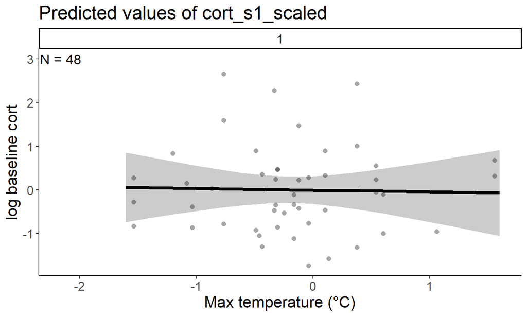

## Cort across temp and habitat: TRES, rc

For original model with min temp:

| model | npar | AIC | BIC | logLik | deviance | Chisq | Df | Pr(>Chisq) |
| --- | --- | --- | --- | --- | --- | --- | --- | --- |
| no sq | 12 | 75.81585 | 90.91301 | -25.90793 | 51.81585 | NA | NA | NA |
| no min sq | 14 | 77.13261 | 94.74596 | -24.56631 | 49.13261 | 2.683239 | 2 | 0.26142200 |
| sq max and min | 15 | 76.40458 | 95.27603 | -23.20229 | 46.40458 | 2.728034 | 1 | 0.09860062 |

| model | npar | AIC | BIC | logLik | deviance | Chisq | Df | Pr(>Chisq) |
| --- | --- | --- | --- | --- | --- | --- | --- | --- |
| no sq | 12 | 75.81585 | 90.91301 | -25.90793 | 51.81585 | NA | NA | NA |
| no max sq | 13 | 75.17586 | 91.53111 | -24.58793 | 49.17586 | 2.639993 | 1 | 0.1042040 |
| sq max and min | 15 | 76.40458 | 95.27603 | -23.20229 | 46.40458 | 2.771280 | 2 | 0.2501637 |

```
## Linear mixed model fit by REML. t-tests use Satterthwaite's method [
## lmerModLmerTest]
## Formula:
## cort_s1_scaled ~ poly(meanmaxtempI_scaled, 2, raw = TRUE) + poly(meanmintempI_scaled,
##     2) + poly(meanmaxtempI_scaled, 2, raw = TRUE) * meanh_scaled +
##     brood_size + age_scaled + juliandate_scaled + (1 | year) +
##     (1 | site/attempt_id)
##    Data:
## (dplyr::filter(g, habitat == "Row crop", Species == "TRES", !is.na(meanmaxtempI),
##     !is.na(cort_s1)) %>% mutate(across(c(cort_s1, meanmaxtempI,
##     meanmintempI, meanh, cort_s1_mother, age, juliandate), ~scale(.x)[,
##     1], .names = "{.col}_scaled"), meanmaxtempI_scaled_sq = meanmaxtempI_scaled *
##     meanmaxtempI_scaled))
##
## REML criterion at convergence: 46.2
##
## Scaled residuals:
##     Min      1Q  Median      3Q     Max
## -1.5718 -0.5486  0.0000  0.4302  1.4128
##
## Random effects:
##  Groups          Name        Variance Std.Dev.
##  attempt_id:site (Intercept) 1.1089   1.0531
##  site            (Intercept) 0.8232   0.9073
##  year            (Intercept) 0.1066   0.3265
##  Residual                    0.6047   0.7776
## Number of obs: 26, groups:  attempt_id:site, 10; site, 3; year, 2
##
## Fixed effects:
##                                                          Estimate Std. Error
## (Intercept)                                            -8.458e+00  1.621e+01
## poly(meanmaxtempI_scaled, 2, raw = TRUE)1               2.100e+00  2.677e+00
## poly(meanmaxtempI_scaled, 2, raw = TRUE)2               2.536e-01  2.943e+00
## poly(meanmintempI_scaled, 2)1                           1.383e+01  2.960e+01
## poly(meanmintempI_scaled, 2)2                          -1.704e+01  3.503e+01
## meanh_scaled                                            8.355e-01  1.669e+00
## brood_size                                              1.514e+00  3.383e+00
## age_scaled                                             -7.681e-01  5.427e+00
## juliandate_scaled                                       4.452e-01  5.436e+00
## poly(meanmaxtempI_scaled, 2, raw = TRUE)1:meanh_scaled -4.266e-01  5.214e+00
```

[output cut: 37 more lines]

```
## p(I_,2,r=TRUE)2: -0.828 -0.282           -0.940           -0.903    0.914
##                  mnh_sc brd_sz ag_scl jlndt_ p(I_,2,r=TRUE)1:
## pl(I_,2,r=TRUE)1
## pl(I_,2,r=TRUE)2
## ply(mI_,2)1
## ply(mI_,2)2
## meanh_scald
## brood_size       -0.751
## age_scaled       -0.831  0.861
## julndt_scld      -0.874  0.955  0.955
## p(I_,2,r=TRUE)1:  0.765 -0.964 -0.904 -0.952
## p(I_,2,r=TRUE)2: -0.844  0.879  0.980  0.958 -0.938
## optimizer (nloptwrap) convergence code: 0 (OK)
## unable to evaluate scaled gradient
## Model failed to converge: degenerate  Hessian with 2 negative eigenvalues
```

Neither squared term contributes much to this fit.

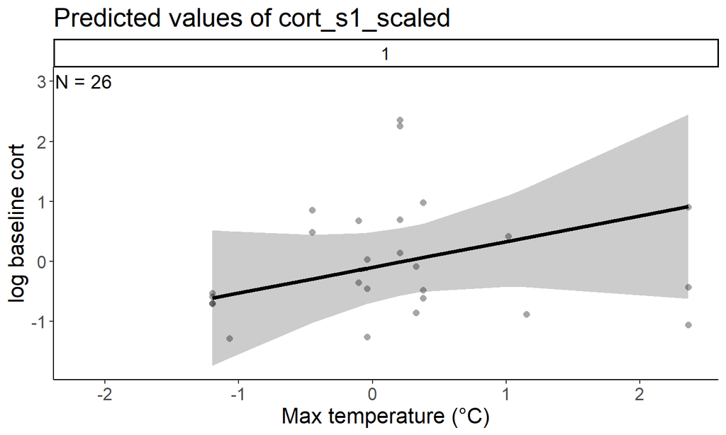

## Cort across temp and habitat: TRES, rc

For updated model based on DAG, squared temp is not supported:

| model | npar | AIC | BIC | logLik | deviance | Chisq | Df | Pr(>Chisq) |
| --- | --- | --- | --- | --- | --- | --- | --- | --- |
| no sq | 8 | 100.7503 | 112.4762 | -42.37515 | 84.75029 | NA | NA | NA |
| sq max temp | 9 | 102.2842 | 115.4758 | -42.14210 | 84.28419 | 0.4660997 | 1 | 0.494787 |

```
## Linear mixed model fit by REML. t-tests use Satterthwaite's method [
## lmerModLmerTest]
## Formula:
## cort_s1_scaled ~ meanmaxtempI_scaled + age_scaled + juliandate_scaled +
##     (1 | year) + (1 | site/attempt_id)
##    Data:
## dplyr::filter(g, habitat == "Row crop", Species == "TRES", !is.na(meanmaxtempI)) %>%
##     mutate(across(c(gweight, meanmaxtempI, meanmintempI, juliandate,
##         brood_size, age, cort_s1), ~scale(.x)[, 1], .names = "{.col}_scaled"),
##         meanmaxtempI_scaled_sq = meanmaxtempI_scaled * meanmaxtempI_scaled)
##
## REML criterion at convergence: 91
##
## Scaled residuals:
##     Min      1Q  Median      3Q     Max
## -1.7317 -0.5789 -0.1316  0.6029  1.8834
##
## Random effects:
##  Groups          Name        Variance Std.Dev.
##  attempt_id:site (Intercept) 0.06533  0.2556
##  site            (Intercept) 0.00000  0.0000
##  year            (Intercept) 0.03416  0.1848
##  Residual                    0.88180  0.9390
## Number of obs: 32, groups:  attempt_id:site, 12; site, 3; year, 2
##
## Fixed effects:
##                     Estimate Std. Error       df t value Pr(>|t|)
## (Intercept)         -0.18840    0.24588  1.08643  -0.766    0.575
## meanmaxtempI_scaled  0.02828    0.19708  7.17384   0.143    0.890
## age_scaled           0.46272    0.25191  7.57131   1.837    0.106
## juliandate_scaled    0.19494    0.18638  7.23173   1.046    0.329
##
## Correlation of Fixed Effects:
##             (Intr) mnmxI_ ag_scl
## mnmxtmpI_sc  0.091
## age_scaled  -0.338 -0.001
## julndt_scld -0.293 -0.383  0.256
## optimizer (nloptwrap) convergence code: 0 (OK)
## boundary (singular) fit: see help('isSingular')
```

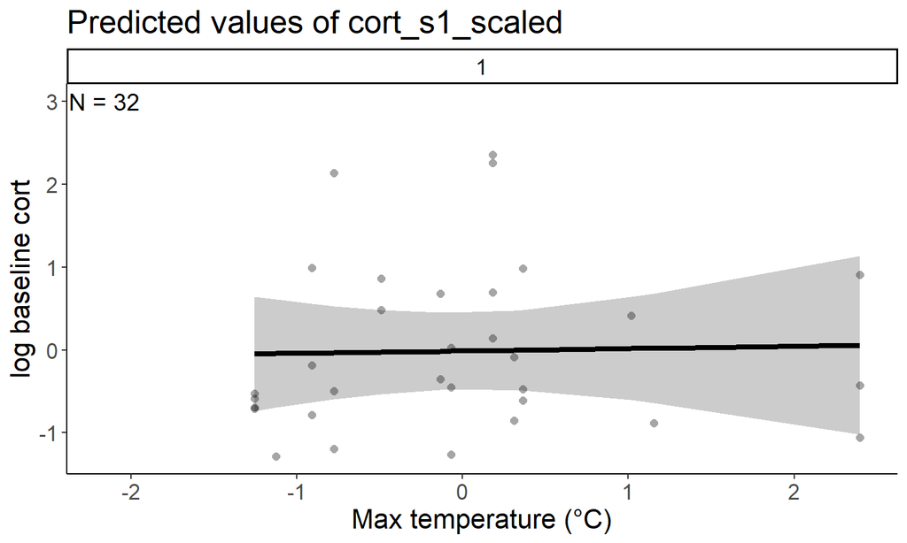

## Conclusions

I have concerns with overfitting in forest and orchard (too few data), but I think we can safely leave squared terms out of this model

| Habitat | Sq max (orig) | Sq min (orig) | Sq max (update) |
| --- | --- | --- | --- |
| Forest | NA | NA | * |
| Orchard | NA | NA | * |
| Grassland |  |  |  |
| Row crop |  |  |  |

## New data! Provisioning ~ temp * habitat: WEBL

Used DAG version 3 in code/dag.Rmd to support model. Below model is canonical adjustment set given outcome = food provisioning and exposure = temp and habitat

Base model: provis ~ temp^2 * habitat + julian_date + nest_age + time_of_day^2 + 1|attempt_id + 1|year

Note: The model was not able to handle the nested random effect of site/attempt_id, so I figured attempt_id could soak up some of that variation and was the more important one. Should I also add folder as a random effect? That could soak up some of the sampling error (some cameras worked better than others, or had slightly different operation)

I have re-aggregated the results to 1 hr, hopefully eliminating the need for a zero-inflated model. There are still zero counts, so hopefully we can discuss how to find out if I still need a zero-inflated model.

Need to answer two questions: - Is the interaction of temp and habitat significant? - Is the second-order term of max temp significant?

In this presentation, I will take a different tack than before: separating across habitats and looking at fit and squared terms individually. But first, let’s see if a poisson distribution fits the count data. Another option would be a binomial distribution since theoretically birds can’t visit their nests an infinite number of times in an hour.

## Provis by time of day: WEBL

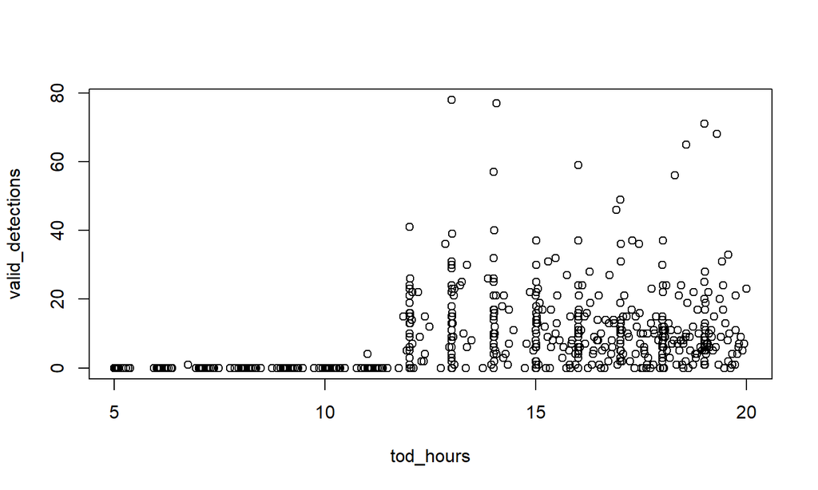

## Provis by time of day: TRES

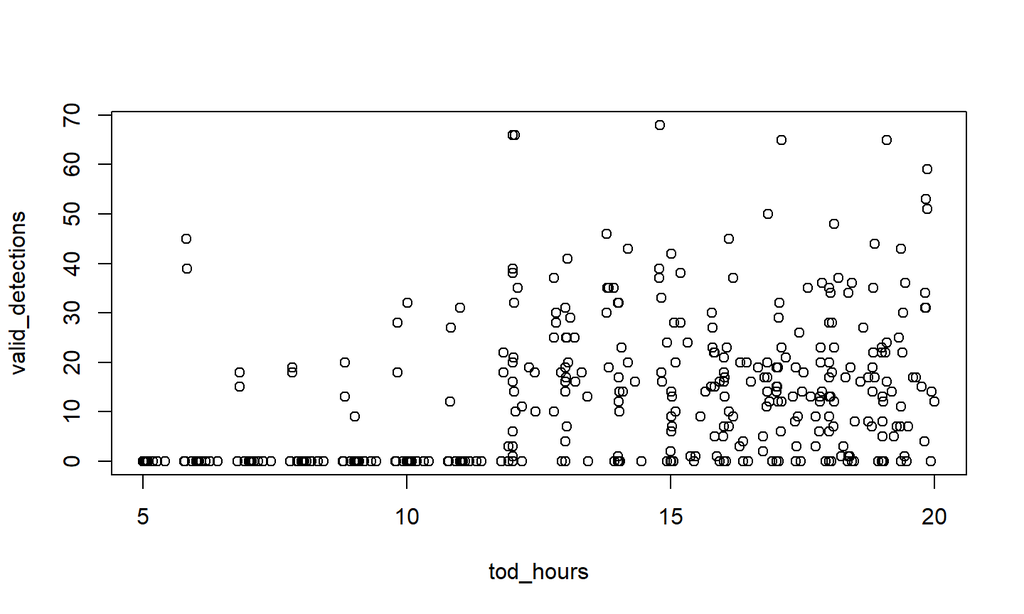

## Histogram of provis

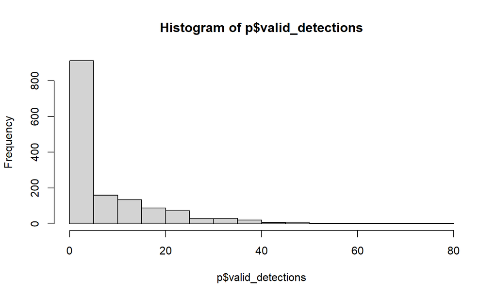

This looks like a poisson distribution would do okay here?

## Base model with poisson distribution

```
##                                        GVIF Df GVIF^(1/(2*Df))
## poly(mean_temp_scaled, 2)         91.658928  2        3.094167
## habitat                            1.250665  3        1.037983
## julian_date_scaled                 3.099586  1        1.760564
## mean_nestling_age_scaled           3.053601  1        1.747456
## poly(tod_scaled, 2)                2.445315  2        1.250500
## year_fct                           1.206329  2        1.048013
## poly(mean_temp_scaled, 2):habitat 93.776735  6        1.459961
```

```
## deviance
##        0
```

This looks like it does not adequately fit the data.

## Let’s try binomial distribution!

```
## deviance
##        0
```

This ran but also doesn’t look like it fits the data well. We may have to use zero inflation after all.

## Let’s try zero inflation!

```
##      deviance
## 4.885747e-284
```

That also doesn’t fit! yikes. Not sure what to do about this. I guess I have to start adding predictors to the zero dispersion??

I tried a few predictors but did not manage to find a zero inflation factor that helps this model fit a little bit better. Hope we can figure this out! For now I’m going to go with the glmmTMB model because it’s most complicated so I’ll work through all the potential problems on the way.

## Plot raw data for WEBL

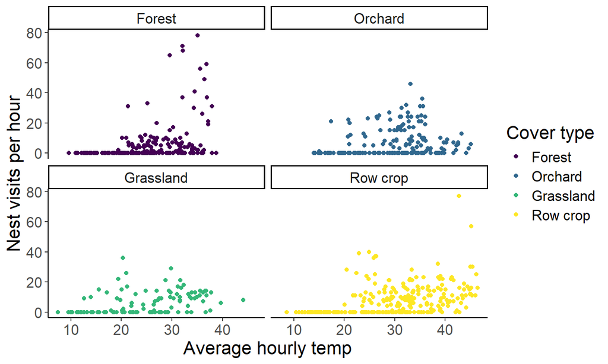

## Provisioning ~ heat * habitat, WEBL, forest

Squared term not supported

| model | Df | AIC | BIC | logLik | deviance | Chisq | Chi Df | Pr(>Chisq) |
| --- | --- | --- | --- | --- | --- | --- | --- | --- |
| no sq | 10 | 753.5837 | 786.1587 | -366.7918 | 733.5837 | NA | NA | NA |
| sq max temp | 11 | 754.0687 | 789.9011 | -366.0343 | 732.0687 | 1.515026 | 1 | 0.2183737 |

```
##  Family: nbinom2  ( log )
## Formula:
## valid_detections ~ mean_temp_scaled + julian_date_scaled + mean_nestling_age_scaled +
##     poly(tod_scaled, 2, raw = TRUE) + (1 | attempt_id) + year_fct
## Zero inflation:                    ~1
## Data:
## dplyr::filter(p, habitat == "Forest", !is.na(mean_temp), !is.na(julian_date),
##     !is.na(mean_nestling_age), !is.na(tod), !is.na(site), !is.na(attempt_id),
##     !is.na(year), species == "WEBL") %>% mutate(across(c(tod,
##     mean_temp, julian_date, mean_nestling_age), ~scale(.x)[,
##     1], .names = "{.col}_scaled"))
##
##      AIC      BIC   logLik deviance df.resid
##    753.6    786.2   -366.8    733.6      182
##
## Random effects:
##
## Conditional model:
##  Groups     Name        Variance  Std.Dev.
##  attempt_id (Intercept) 6.112e-11 7.818e-06
## Number of obs: 192, groups:  attempt_id, 6
##
## Dispersion parameter for nbinom2 family (): 0.65
##
## Conditional model:
##                                  Estimate Std. Error z value Pr(>|z|)
## (Intercept)                        1.7573     0.3390   5.184 2.17e-07 ***
## mean_temp_scaled                  -0.7117     0.3225  -2.207   0.0273 *
## julian_date_scaled                -0.4082     0.2354  -1.734   0.0829 .
## mean_nestling_age_scaled           0.9135     0.2022   4.517 6.26e-06 ***
## poly(tod_scaled, 2, raw = TRUE)1   3.7585     0.4966   7.569 3.76e-14 ***
## poly(tod_scaled, 2, raw = TRUE)2  -2.1365     0.4199  -5.088 3.61e-07 ***
## year_fct2023                      -0.7585     0.3235  -2.345   0.0190 *
## ---
## Signif. codes:  0 '***' 0.001 '**' 0.01 '*' 0.05 '.' 0.1 ' ' 1
##
## Zero-inflation model:
##             Estimate Std. Error z value Pr(>|z|)
## (Intercept)   -20.41    5061.46  -0.004    0.997
```

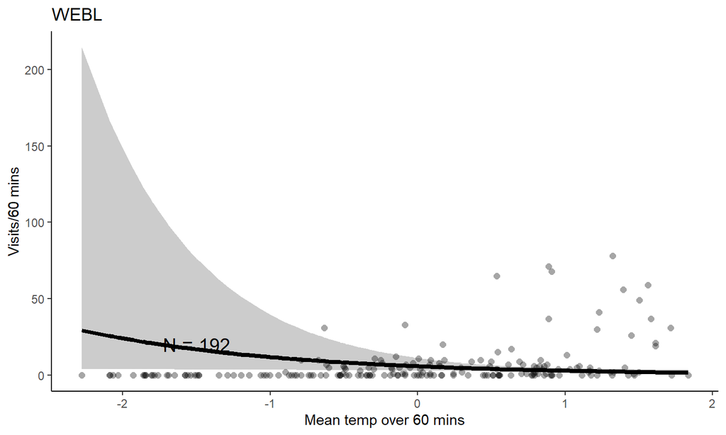

## Provisioning ~ heat * habitat, WEBL, orchard

Squared term not supported

| model | Df | AIC | BIC | logLik | deviance | Chisq | Chi Df | Pr(>Chisq) |
| --- | --- | --- | --- | --- | --- | --- | --- | --- |
| no sq | 11 | 758.9840 | 793.2819 | -368.4920 | 736.9840 | NA | NA | NA |
| sq max temp | 12 | 760.7137 | 798.1296 | -368.3568 | 736.7137 | 0.2703416 | 1 | 0.6031027 |

```
##  Family: nbinom2  ( log )
## Formula:
## valid_detections ~ mean_temp_scaled + julian_date_scaled + mean_nestling_age_scaled +
##     poly(tod_scaled, 2, raw = TRUE) + (1 | attempt_id) + year_fct
## Zero inflation:                    ~1
## Data:
## dplyr::filter(p, habitat == "Orchard", !is.na(mean_temp), !is.na(julian_date),
##     !is.na(mean_nestling_age), !is.na(tod), !is.na(site), !is.na(attempt_id),
##     !is.na(year), species == "WEBL") %>% mutate(across(c(tod,
##     mean_temp, julian_date, mean_nestling_age), ~scale(.x)[,
##     1], .names = "{.col}_scaled"))
##
##      AIC      BIC   logLik deviance df.resid
##    759.0    793.3   -368.5    737.0      156
##
## Random effects:
##
## Conditional model:
##  Groups     Name        Variance Std.Dev.
##  attempt_id (Intercept) 0.01043  0.1021
## Number of obs: 167, groups:  attempt_id, 12
##
## Dispersion parameter for nbinom2 family (): 2.19
##
## Conditional model:
##                                  Estimate Std. Error z value Pr(>|z|)
## (Intercept)                       2.02370    0.39238   5.157 2.50e-07 ***
## mean_temp_scaled                 -0.39128    0.25193  -1.553   0.1204
## julian_date_scaled               -0.32171    0.18964  -1.696   0.0898 .
## mean_nestling_age_scaled          0.32053    0.08196   3.911 9.19e-05 ***
## poly(tod_scaled, 2, raw = TRUE)1  2.48820    0.34687   7.173 7.32e-13 ***
## poly(tod_scaled, 2, raw = TRUE)2 -1.91952    0.37029  -5.184 2.17e-07 ***
## year_fct2022                      0.06948    0.35056   0.198   0.8429
## year_fct2023                      0.29334    0.40111   0.731   0.4646
## ---
## Signif. codes:  0 '***' 0.001 '**' 0.01 '*' 0.05 '.' 0.1 ' ' 1
##
## Zero-inflation model:
##             Estimate Std. Error z value Pr(>|z|)
## (Intercept)  -1.8101     0.3933  -4.602 4.19e-06 ***
## ---
## Signif. codes:  0 '***' 0.001 '**' 0.01 '*' 0.05 '.' 0.1 ' ' 1
```

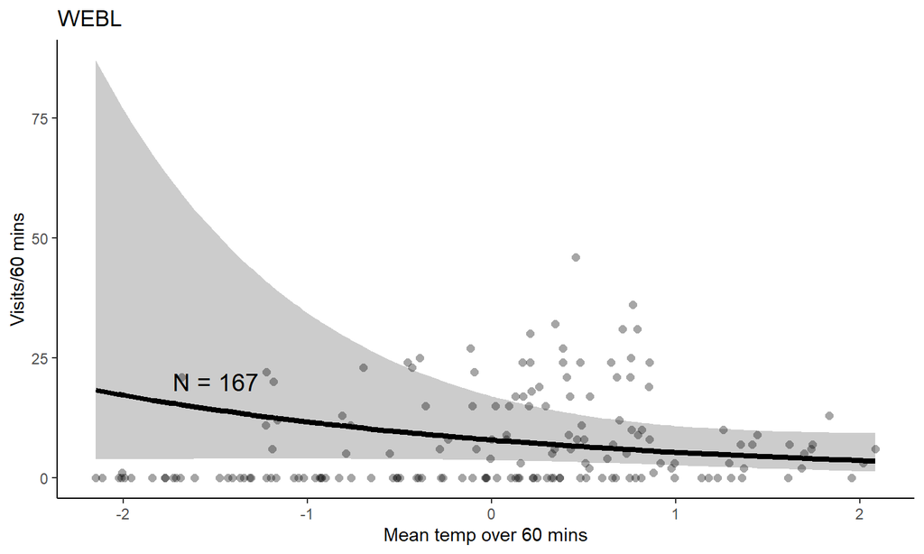

## Provisioning ~ heat * habitat, WEBL, grassland

Squared term not supported

| model | Df | AIC | BIC | logLik | deviance | Chisq | Chi Df | Pr(>Chisq) |
| --- | --- | --- | --- | --- | --- | --- | --- | --- |
| no sq | 11 | 504.5684 | 534.1732 | -241.2842 | 482.5684 | NA | NA | NA |
| sq max temp | 12 | 506.3523 | 538.6485 | -241.1762 | 482.3523 | 0.2160788 | 1 | 0.642044 |

```
##  Family: nbinom2  ( log )
## Formula:
## valid_detections ~ mean_temp_scaled + julian_date_scaled + mean_nestling_age_scaled +
##     poly(tod_scaled, 2, raw = TRUE) + (1 | attempt_id) + year_fct
## Zero inflation:                    ~1
## Data:
## dplyr::filter(p, habitat == "Grassland", !is.na(mean_temp), !is.na(julian_date),
##     !is.na(mean_nestling_age), !is.na(tod), !is.na(site), !is.na(attempt_id),
##     !is.na(year), species == "WEBL") %>% mutate(across(c(tod,
##     mean_temp, julian_date, mean_nestling_age), ~scale(.x)[,
##     1], .names = "{.col}_scaled"))
##
##      AIC      BIC   logLik deviance df.resid
##    504.6    534.2   -241.3    482.6       98
##
## Random effects:
##
## Conditional model:
##  Groups     Name        Variance  Std.Dev.
##  attempt_id (Intercept) 6.823e-10 2.612e-05
## Number of obs: 109, groups:  attempt_id, 6
##
## Dispersion parameter for nbinom2 family (): 2.09
##
## Conditional model:
##                                  Estimate Std. Error z value Pr(>|z|)
## (Intercept)                        1.8932     0.7955   2.380   0.0173 *
## mean_temp_scaled                   0.1091     0.2809   0.388   0.6978
## julian_date_scaled                -0.5967     0.5231  -1.141   0.2540
## mean_nestling_age_scaled           0.1348     0.1576   0.855   0.3924
## poly(tod_scaled, 2, raw = TRUE)1   1.9468     0.3957   4.920 8.66e-07 ***
## poly(tod_scaled, 2, raw = TRUE)2  -1.8852     0.3611  -5.220 1.78e-07 ***
## year_fct2022                       0.6332     0.6348   0.997   0.3186
## year_fct2023                       0.2929     1.1055   0.265   0.7910
## ---
## Signif. codes:  0 '***' 0.001 '**' 0.01 '*' 0.05 '.' 0.1 ' ' 1
##
## Zero-inflation model:
##             Estimate Std. Error z value Pr(>|z|)
## (Intercept)   -1.826      0.588  -3.106   0.0019 **
## ---
## Signif. codes:  0 '***' 0.001 '**' 0.01 '*' 0.05 '.' 0.1 ' ' 1
```

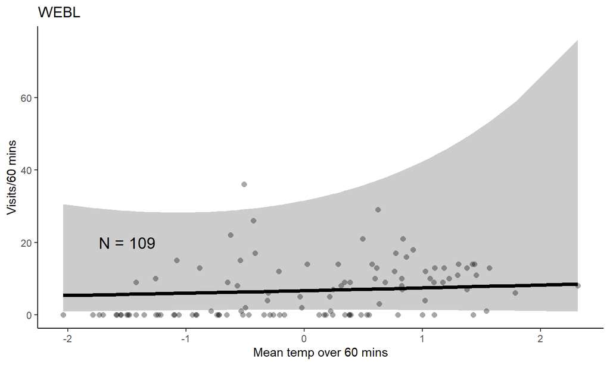

## Provisioning ~ heat * habitat, WEBL, row crop

Squared term is supported! Woww

| model | Df | AIC | BIC | logLik | deviance | Chisq | Chi Df | Pr(>Chisq) |
| --- | --- | --- | --- | --- | --- | --- | --- | --- |
| no sq | 10 | 1227.190 | 1262.987 | -603.5949 | 1207.190 | NA | NA | NA |
| sq max temp | 11 | 1217.508 | 1256.885 | -597.7539 | 1195.508 | 11.68213 | 1 | 0.0006310312 |

```
##  Family: nbinom2  ( log )
## Formula:
## valid_detections ~ poly(mean_temp_scaled, 2, raw = TRUE) + julian_date_scaled +
##     mean_nestling_age_scaled + poly(tod_scaled, 2, raw = TRUE) +
##     (1 | attempt_id) + year_fct
## Zero inflation:                    ~1
## Data:
## dplyr::filter(p, habitat == "Row crop", !is.na(mean_temp), !is.na(julian_date),
##     !is.na(mean_nestling_age), !is.na(tod), !is.na(site), !is.na(attempt_id),
##     !is.na(year), species == "WEBL") %>% mutate(across(c(tod,
##     mean_temp, julian_date, mean_nestling_age), ~scale(.x)[,
##     1], .names = "{.col}_scaled"))
##
##      AIC      BIC   logLik deviance df.resid
##   1217.5   1256.9   -597.8   1195.5      254
##
## Random effects:
##
## Conditional model:
##  Groups     Name        Variance Std.Dev.
##  attempt_id (Intercept) 0.118    0.3435
## Number of obs: 265, groups:  attempt_id, 8
##
## Dispersion parameter for nbinom2 family (): 2.11
##
## Conditional model:
##                                        Estimate Std. Error z value Pr(>|z|)
## (Intercept)                             2.61040    0.26137   9.988  < 2e-16 ***
## poly(mean_temp_scaled, 2, raw = TRUE)1 -0.85945    0.21806  -3.941  8.1e-05 ***
## poly(mean_temp_scaled, 2, raw = TRUE)2  0.39274    0.11339   3.464 0.000533 ***
## julian_date_scaled                      0.23474    0.15920   1.474 0.140352
## mean_nestling_age_scaled                0.04147    0.08131   0.510 0.610022
## poly(tod_scaled, 2, raw = TRUE)1        3.17890    0.23892  13.305  < 2e-16 ***
## poly(tod_scaled, 2, raw = TRUE)2       -2.71037    0.23574 -11.497  < 2e-16 ***
## year_fct2023                           -0.31587    0.30827  -1.025 0.305540
## ---
## Signif. codes:  0 '***' 0.001 '**' 0.01 '*' 0.05 '.' 0.1 ' ' 1
##
## Zero-inflation model:
##             Estimate Std. Error z value Pr(>|z|)
## (Intercept)   -5.995      5.508  -1.088    0.276
```

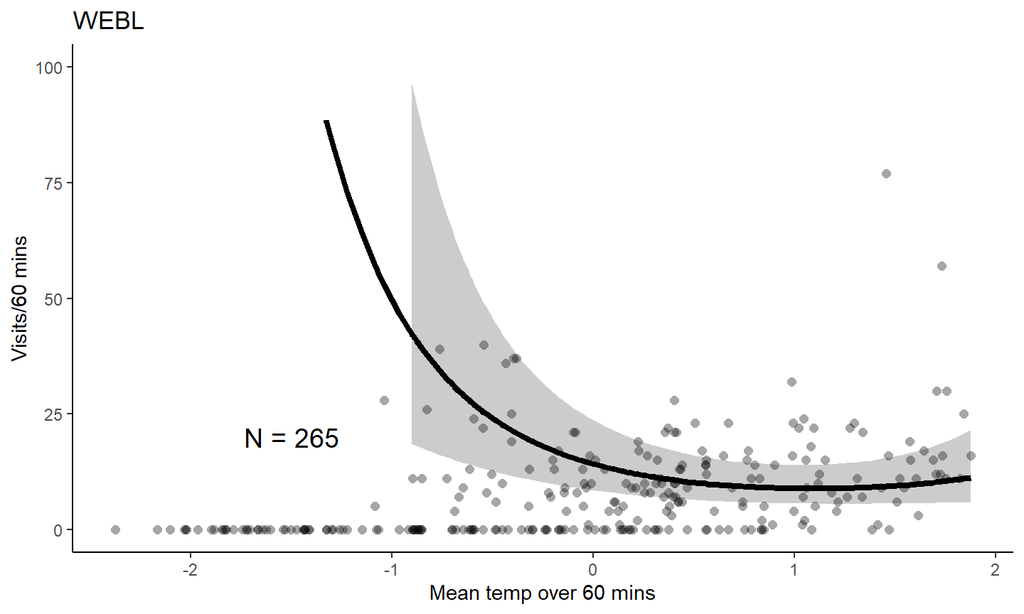

## Conclusions

Squared temp is important in row crop. Let’s discuss!

| Habitat | Sq max (orig) | Sq min (orig) | Sq max (update) |
| --- | --- | --- | --- |
| Forest | NA | NA |  |
| Orchard | NA | NA |  |
| Grassland | NA | NA |  |
| Row crop | NA | NA | * |

## Plot raw data for TRES

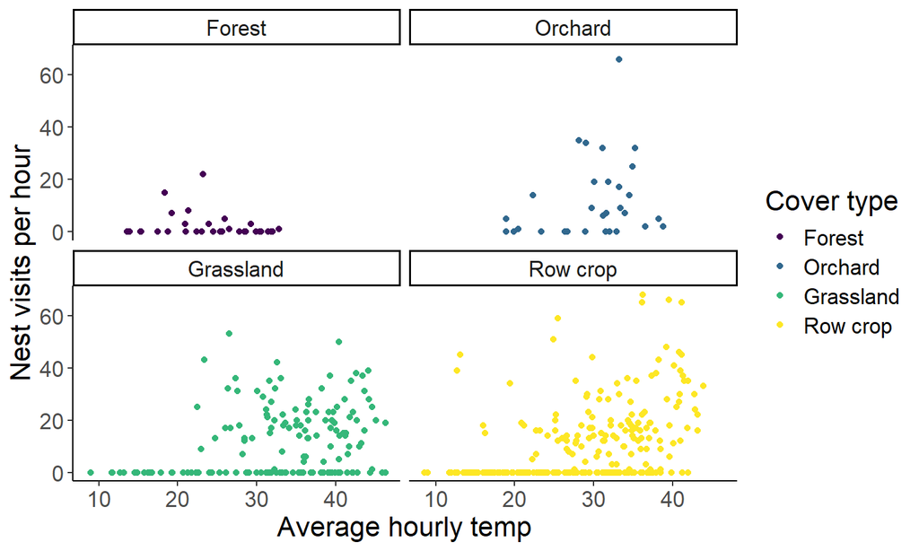

## Provisioning ~ heat * habitat, TRES, forest

Squared term not supported

| model | Df | AIC | BIC | logLik | deviance | Chisq | Chi Df | Pr(>Chisq) |
| --- | --- | --- | --- | --- | --- | --- | --- | --- |
| no sq | 10 | 75.20560 | 90.17068 | -27.60280 | 55.20560 | NA | NA | NA |
| sq max temp | 11 | 76.99889 | 93.46047 | -27.49944 | 54.99889 | 0.206715 | 1 | 0.6493545 |

```
##  Family: nbinom2  ( log )
## Formula:
## valid_detections ~ mean_temp_scaled + julian_date_scaled + mean_nestling_age_scaled +
##     poly(tod_scaled, 2, raw = TRUE) + (1 | attempt_id) + year_fct
## Zero inflation:                    ~1
## Data:
## dplyr::filter(p, habitat == "Forest", !is.na(mean_temp), !is.na(julian_date),
##     !is.na(mean_nestling_age), !is.na(tod), !is.na(site), !is.na(attempt_id),
##     !is.na(year), species == "TRES") %>% mutate(across(c(tod,
##     mean_temp, julian_date, mean_nestling_age), ~scale(.x)[,
##     1], .names = "{.col}_scaled"))
##
##      AIC      BIC   logLik deviance df.resid
##     75.2     90.2    -27.6     55.2       23
##
## Random effects:
##
## Conditional model:
##  Groups     Name        Variance  Std.Dev.
##  attempt_id (Intercept) 5.737e-15 7.574e-08
## Number of obs: 33, groups:  attempt_id, 4
##
## Dispersion parameter for nbinom2 family (): 12.2
##
## Conditional model:
##                                  Estimate Std. Error z value Pr(>|z|)
## (Intercept)                       1.28504    3.10542   0.414  0.67902
## mean_temp_scaled                 -0.87280    2.78101  -0.314  0.75364
## julian_date_scaled               -1.33645    1.21997  -1.095  0.27331
## mean_nestling_age_scaled          0.01215    0.49515   0.024  0.98043
## poly(tod_scaled, 2, raw = TRUE)1  1.44165    1.06515   1.353  0.17590
## poly(tod_scaled, 2, raw = TRUE)2 -0.16734    3.61937  -0.046  0.96312
## year_fct2023                     -3.69818    1.28739  -2.873  0.00407 **
## ---
## Signif. codes:  0 '***' 0.001 '**' 0.01 '*' 0.05 '.' 0.1 ' ' 1
##
## Zero-inflation model:
##             Estimate Std. Error z value Pr(>|z|)
## (Intercept)   -22.05   20496.67  -0.001    0.999
```

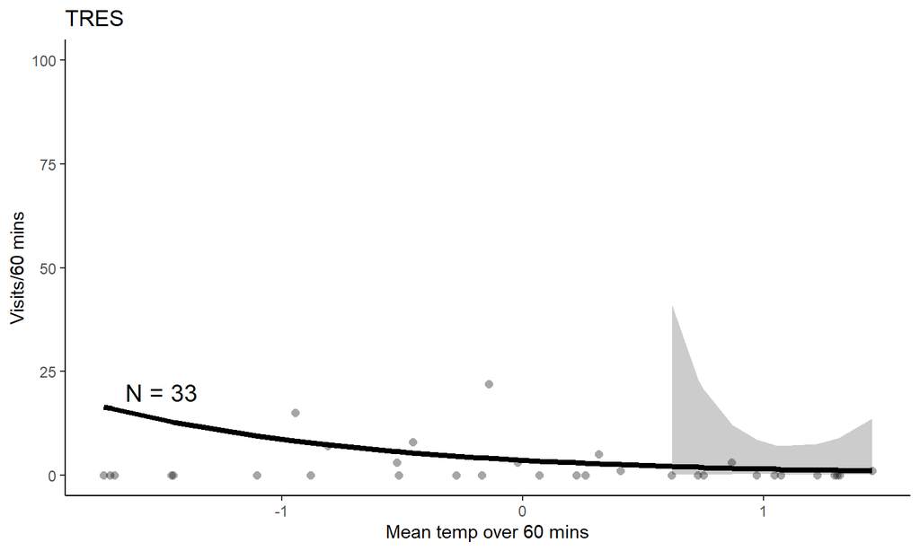

## Provisioning ~ heat * habitat, TRES, orchard

Squared term supported - but looks overfit to me?

| model | Df | AIC | BIC | logLik | deviance | Chisq | Chi Df | Pr(>Chisq) |
| --- | --- | --- | --- | --- | --- | --- | --- | --- |
| no sq | 10 | 194.6944 | 209.0343 | -87.34722 | 174.6944 | NA | NA | NA |
| sq max temp | 11 | 182.4210 | 198.1948 | -80.21049 | 160.4210 | 14.27347 | 1 | 0.0001580774 |

```
##  Family: nbinom2  ( log )
## Formula:
## valid_detections ~ poly(mean_temp_scaled, 2, raw = TRUE) + julian_date_scaled +
##     mean_nestling_age_scaled + poly(tod_scaled, 2, raw = TRUE) +
##     (1 | attempt_id) + year_fct
## Zero inflation:                    ~1
## Data:
## dplyr::filter(p, habitat == "Orchard", !is.na(mean_temp), !is.na(julian_date),
##     !is.na(mean_nestling_age), !is.na(tod), !is.na(site), !is.na(attempt_id),
##     !is.na(year), species == "TRES") %>% mutate(across(c(tod,
##     mean_temp, julian_date, mean_nestling_age), ~scale(.x)[,
##     1], .names = "{.col}_scaled"))
##
##      AIC      BIC   logLik deviance df.resid
##    182.4    198.2    -80.2    160.4       20
##
## Random effects:
##
## Conditional model:
##  Groups     Name        Variance  Std.Dev.
##  attempt_id (Intercept) 9.955e-11 9.978e-06
## Number of obs: 31, groups:  attempt_id, 3
##
## Dispersion parameter for nbinom2 family (): 26.5
##
## Conditional model:
##                                        Estimate Std. Error z value Pr(>|z|)
## (Intercept)                             3.10497    0.25042  12.399  < 2e-16 ***
## poly(mean_temp_scaled, 2, raw = TRUE)1 -0.12728    0.28829  -0.441    0.659
## poly(mean_temp_scaled, 2, raw = TRUE)2 -0.68126    0.16333  -4.171 3.03e-05 ***
## julian_date_scaled                     -0.02534    0.19759  -0.128    0.898
## mean_nestling_age_scaled                0.21765    0.18136   1.200    0.230
## poly(tod_scaled, 2, raw = TRUE)1       -1.41062    0.25241  -5.589 2.29e-08 ***
## poly(tod_scaled, 2, raw = TRUE)2        1.86448    0.31415   5.935 2.94e-09 ***
## year_fct2023                           -0.53275    0.37662  -1.415    0.157
## ---
## Signif. codes:  0 '***' 0.001 '**' 0.01 '*' 0.05 '.' 0.1 ' ' 1
##
## Zero-inflation model:
##             Estimate Std. Error z value Pr(>|z|)
## (Intercept)  -0.7419     0.3842  -1.931   0.0535 .
## ---
## Signif. codes:  0 '***' 0.001 '**' 0.01 '*' 0.05 '.' 0.1 ' ' 1
```

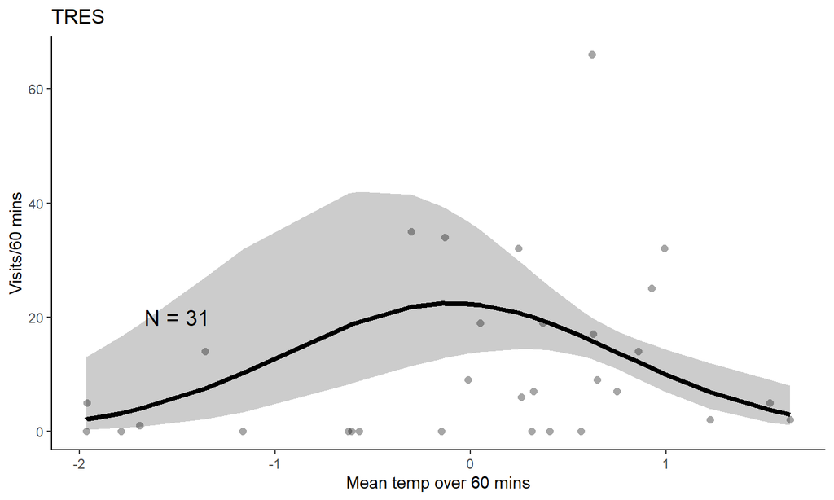

## Provisioning ~ heat * habitat, TRES, grassland

Squared term not supported

| model | Df | AIC | BIC | logLik | deviance | Chisq | Chi Df | Pr(>Chisq) |
| --- | --- | --- | --- | --- | --- | --- | --- | --- |
| no sq | 11 | 895.8481 | 929.9467 | -436.9241 | 873.8481 | NA | NA | NA |
| sq max temp | 12 | 897.8117 | 935.0101 | -436.9058 | 873.8117 | 0.03643984 | 1 | 0.84861 |

```
##  Family: nbinom2  ( log )
## Formula:
## valid_detections ~ mean_temp_scaled + julian_date_scaled + mean_nestling_age_scaled +
##     poly(tod_scaled, 2, raw = TRUE) + (1 | attempt_id) + year_fct
## Zero inflation:                    ~1
## Data:
## dplyr::filter(p, habitat == "Grassland", !is.na(mean_temp), !is.na(julian_date),
##     !is.na(mean_nestling_age), !is.na(tod), !is.na(site), !is.na(attempt_id),
##     !is.na(year), species == "TRES") %>% mutate(across(c(tod,
##     mean_temp, julian_date, mean_nestling_age), ~scale(.x)[,
##     1], .names = "{.col}_scaled"))
##
##      AIC      BIC   logLik deviance df.resid
##    895.8    929.9   -436.9    873.8      153
##
## Random effects:
##
## Conditional model:
##  Groups     Name        Variance  Std.Dev.
##  attempt_id (Intercept) 2.712e-10 1.647e-05
## Number of obs: 164, groups:  attempt_id, 9
##
## Dispersion parameter for nbinom2 family (): 5.09
##
## Conditional model:
##                                  Estimate Std. Error z value Pr(>|z|)
## (Intercept)                       3.13972    0.19407  16.179  < 2e-16 ***
## mean_temp_scaled                  0.15093    0.14708   1.026  0.30482
## julian_date_scaled                0.13355    0.10148   1.316  0.18819
## mean_nestling_age_scaled          0.35019    0.10282   3.406  0.00066 ***
## poly(tod_scaled, 2, raw = TRUE)1 -0.02658    0.16384  -0.162  0.87115
## poly(tod_scaled, 2, raw = TRUE)2  0.32274    0.22028   1.465  0.14288
## year_fct2022                     -0.75342    0.26453  -2.848  0.00440 **
## year_fct2023                     -0.41017    0.29155  -1.407  0.15946
## ---
## Signif. codes:  0 '***' 0.001 '**' 0.01 '*' 0.05 '.' 0.1 ' ' 1
##
## Zero-inflation model:
##             Estimate Std. Error z value Pr(>|z|)
## (Intercept)  -0.1472     0.1566   -0.94    0.347
```

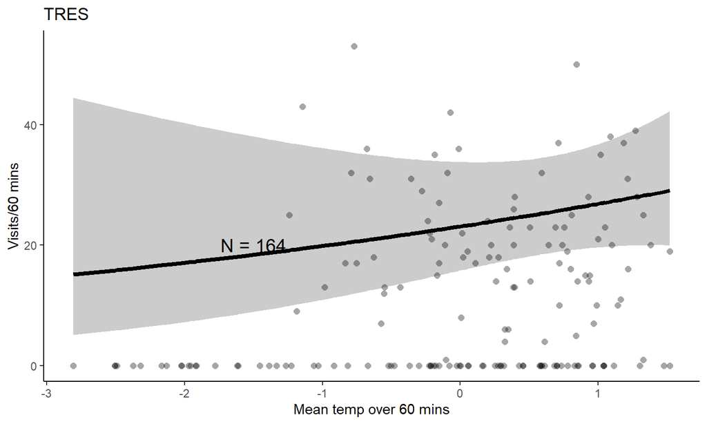

## Provisioning ~ heat * habitat, TRES, row crop

Squared term not supported

| model | Df | AIC | BIC | logLik | deviance | Chisq | Chi Df | Pr(>Chisq) |
| --- | --- | --- | --- | --- | --- | --- | --- | --- |
| no sq | 11 | 1286.523 | 1325.127 | -632.2617 | 1264.523 | NA | NA | NA |
| sq max temp | 12 | 1287.142 | 1329.254 | -631.5709 | 1263.142 | 1.381612 | 1 | 0.2398268 |

```
##  Family: nbinom2  ( log )
## Formula:
## valid_detections ~ mean_temp_scaled + julian_date_scaled + mean_nestling_age_scaled +
##     poly(tod_scaled, 2, raw = TRUE) + (1 | attempt_id) + year_fct
## Zero inflation:                    ~1
## Data:
## dplyr::filter(p, habitat == "Row crop", !is.na(mean_temp), !is.na(julian_date),
##     !is.na(mean_nestling_age), !is.na(tod), !is.na(site), !is.na(attempt_id),
##     !is.na(year), species == "TRES") %>% mutate(across(c(tod,
##     mean_temp, julian_date, mean_nestling_age), ~scale(.x)[,
##     1], .names = "{.col}_scaled"))
##
##      AIC      BIC   logLik deviance df.resid
##   1286.5   1325.1   -632.3   1264.5      236
##
## Random effects:
##
## Conditional model:
##  Groups     Name        Variance Std.Dev.
##  attempt_id (Intercept) 0.04963  0.2228
## Number of obs: 247, groups:  attempt_id, 8
##
## Dispersion parameter for nbinom2 family ():  4.2
##
## Conditional model:
##                                  Estimate Std. Error z value Pr(>|z|)
## (Intercept)                       3.22627    0.22359  14.430  < 2e-16 ***
## mean_temp_scaled                  0.22077    0.13154   1.678  0.09329 .
## julian_date_scaled                0.25454    0.13757   1.850  0.06427 .
## mean_nestling_age_scaled         -0.12592    0.06496  -1.938  0.05258 .
## poly(tod_scaled, 2, raw = TRUE)1 -0.28391    0.13329  -2.130  0.03317 *
## poly(tod_scaled, 2, raw = TRUE)2  0.28531    0.13014   2.192  0.02836 *
## year_fct2022                     -1.19431    0.37176  -3.213  0.00132 **
## year_fct2023                     -0.66047    0.31588  -2.091  0.03654 *
## ---
## Signif. codes:  0 '***' 0.001 '**' 0.01 '*' 0.05 '.' 0.1 ' ' 1
##
## Zero-inflation model:
##             Estimate Std. Error z value Pr(>|z|)
## (Intercept) 0.007118   0.127322   0.056    0.955
```

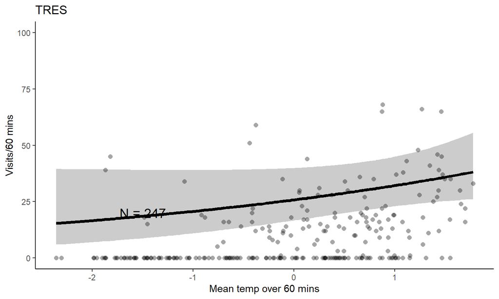

## Conclusions

[output not shown]